# Can every number in a coach report be trusted?

Project 13: a data quality layer for a baseball training facility

Author

Luke Wolff, BSF Performance

Published

October 17, 2026

## Why this matters

A facility’s analytics platform pulls from several feeds at once: a pitch tracker, force plates, hand-entered range-of-motion measurements and a roster. When one feed goes wrong the report usually still looks fine; it is just wrong. A coach who catches one bad number stops trusting all of them.

This project is an automated set of checks that runs on every data load and stops bad numbers before they reach a report, plus a test harness that proves each check works.

## What the real data showed

The same checks were run on a real facility’s archive: about 200,000 pitches and 1,900 force-plate trials. These are rounded results. Five of the ten checks found real problems.

- **Fields that were never filled.** The tracker’s team field and all three game-outcome fields (pitch result, batter, exit speed) were 0% populated. Code that used the team field to tell high school from college athletes was silently wrong.
- **Identities that don’t connect.** About 3 in 4 tracker ids, holding two-thirds of the pitches, link to no athlete in the force-plate system. Those pitches can’t be used in any analysis that needs age or level.
- **Evening tests on the wrong day.** Force-plate times are stored in UTC, so a 7 pm test in the Central time zone is already tomorrow. Read the simple way, about 1 in 6 athlete test-days lands on the wrong date.
- **Short force tests.** About 1 in 9 jump and push-up tests was saved with fewer than the three trials the protocol calls for.
- **Small things.** 35 spin readings above 4,000 rpm (under 0.1% of pitches), 0.3% of pitch rows with no pitch id, and no pitch loaded twice.

**A documented “fact” that didn’t hold.** 56% of pitches have no pitch-type tag. An earlier analysis had found slower throwers tagged more often (r = -0.29). Run on the full archive, the tagging-bias check found no real link to velocity (r = -0.05) and passes. What is uneven is *who* gets tagged: the facility’s own athletes about 69% of the time, other pitchers on the tracker about 43%. Velocity doesn’t wait on tags either way: an all-pitch 95th percentile matched tagged-fastball velocity at r = 0.997 (mean error 0.5 mph).

## The checks

| Check | What it catches | Written in |
| --- | --- | --- |
| Empty columns | A field that is never filled | R |
| Impossible values | Velocity, spin, jump height or range of motion outside physical limits | SQL (and separately in `pointblank`) |
| Duplicate rows | The same pitch loaded twice when exports overlap | SQL |
| Unlinked tracker ids | Pitches that map to no athlete | SQL |
| Orphan links | Links to athletes missing from the roster | SQL |
| Time-zone day shift | Tests filed under the UTC day instead of the local day | R |
| Biased tag missingness | Tags missing more for faster (or slower) pitchers | R, correlation across pitchers |
| Device drift | A force plate whose readings creep over time | R, recent vs earlier sessions |
| Incomplete sessions | Force tests saved with fewer trials than the protocol | SQL |
| Out-of-range dates | Dates before the system existed or after today | SQL |

Every threshold lives in one settings file (`checks.yml`), not in the code.

## Testing the checks on a simulated facility

Real athlete data stays private, so the checks are tested on a simulated facility: 150 athletes, 15,051 pitches and 732 force-plate trials, shaped like the real tables. The simulator can also plant one kind of error for each check, and it keeps an answer key of exactly what it planted.

| Check | Clean data | Planted errors | Rows flagged |
| --- | --- | --- | --- |
| empty_columns | pass | fail | 1 |
| impossible_values | pass | fail | 14 |
| duplicate_rows | pass | fail | 15 |
| unlinked_tracker_ids | pass | fail | 2 |
| orphan_links | pass | fail | 2 |
| timezone_day_shift | pass | fail | 216 |
| biased_tag_missingness | pass | fail | 1 |
| device_drift | pass | fail | 1 |
| incomplete_sessions | pass | fail | 4 |
| out_of_range_dates | pass | fail | 3 |

On clean data every check passes. With errors planted, every check fails, and the tests confirm each rule check flagged **exactly** the planted rows, no more and no fewer.

### Seeing the tagging bias

The bias check asks one question: across pitchers, does the share of pitches that got tagged depend on how hard they throw? On clean data it doesn’t. On the planted data, harder throwers are tagged less, planted strongly so it is easy to see. (On the real archive this check passes; see above.)

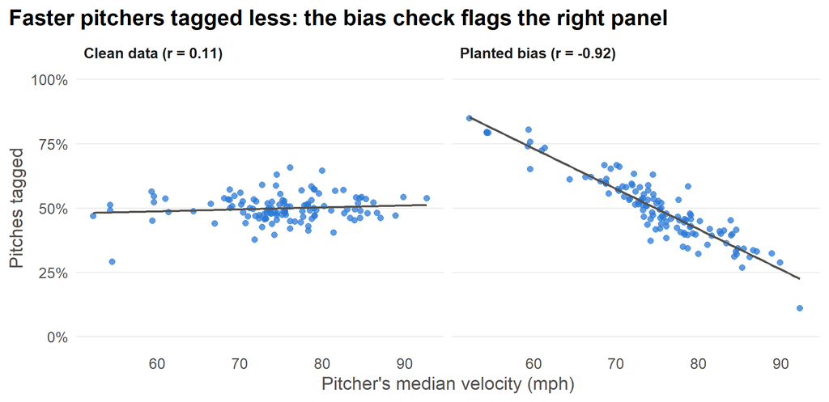

## How often are the statistical checks wrong?

Most checks are rules: a duplicate is a duplicate. Two of them are judgments made from noisy data, so on any one dataset they can be wrong. Rather than trust a single run, they were run on 200 simulated facilities, with and without a planted problem.

- **Tagging bias:** false alarm on clean data 1.0% of the time; planted bias caught 100% of the time.
- **Device drift:** how often a drifting force plate is flagged, by size of the drift:

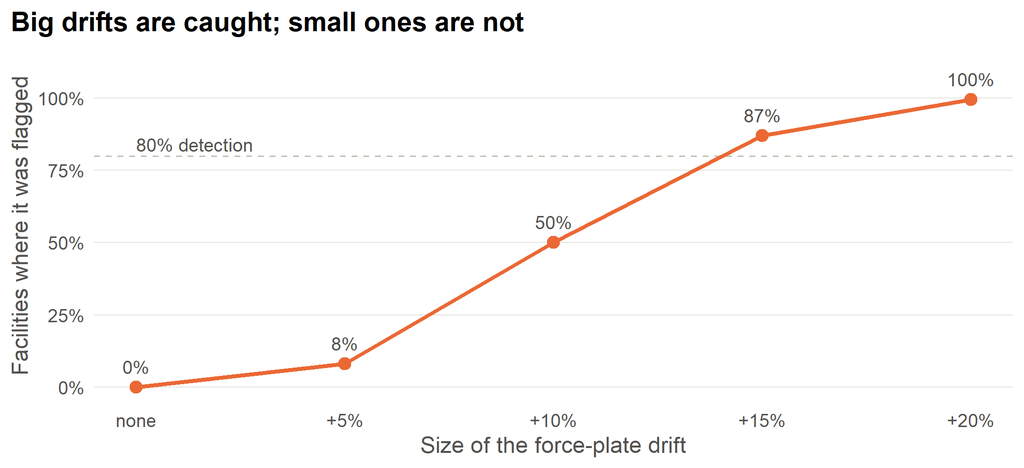

| Drift | Flagged |
| --- | --- |
| none | 0.0% |
| +5% | 8.0% |
| +10% | 50.0% |
| +15% | 87.0% |
| +20% | 99.5% |

**What that means:** with this facility’s testing volume, the drift check never cries wolf but only reliably catches drifts of about 15% or more. A smaller calibration problem needs a different tool, such as a scheduled reference test on each plate, not a smarter formula. Knowing a check’s limits is part of the check.

## Limitations

- The simulator is built from what the real data looked like; a failure nobody has seen yet has no check until it happens once.
- The real run showed where the simulated shape was wrong: two force tests (hop test and mid-thigh pull) are run as one or two trials, not three, so the short-test count above covers the three-trial tests only. It also found two bugs in the checks themselves (a crash on an empty table, and rows with no pitch id counted as one duplicate). Each now has a test.
- Range-of-motion measurements are hand-entered and were not part of the archive run.
- The physical limits and drift thresholds are judgment calls, kept in one settings file so they can be argued about and changed in one place.

## Code

All code and tests are in this project’s folder: the simulator (`synthetic/`), the checks (`13-data-quality/R/` and `sql/`), and the tests (`13-data-quality/tests/`).